# Coursework Report

*N* removed NAs: 2

*N* removed typo: 1

*N* removed <18: 30

*N* total clean: 118

| Group | *N* | *M*<sub>age</sub> | *M*<sub>rating</sub> |
| --- | --- | --- | --- |
| Control | 62 | 20.6 | 6.78 |
| Experim | 56 | 20.7 | 5.72 |

**Main analysis results**

*t*(116) = 7.62, *p* < .001

[interactive chart not shown]

[figure not shown]

[interactive chart not shown]

# Coursework Report

Analysing Data, Spring 2020

# Methods

## Participants

Table 1 *Descriptive Statistics by Age*

| *M*<sub>age</sub> | *SD*<sub>age</sub> | Min | Max |
| --- | --- | --- | --- |
| 20.6 | 1.75 | 18 | 26 |

Table 2 *Descriptive Statistics by Condition*

| Condition | *N* | Question 1 | Question 2 | Question 3 | Composite Score |
| --- | --- | --- | --- | --- | --- |
| control | 62 | 6.65 | 6.92 | 6.77 | 6.78 |
| experimental | 56 | 5.80 | 5.62 | 5.73 | 5.72 |

Table 3 *Descriptive statistics of Age by Condition*

| Condition | *N* | % | *M*<sub>age</sub> | *SD*<sub>age</sub> |
| --- | --- | --- | --- | --- |
| control | 62 | 52.5 | 20.6 | 1.76 |
| experimental | 56 | 47.5 | 20.7 | 1.74 |

## Design

The aim of the experiment was to see if the colours white and red had an effect on women’s perception of attractiveness of a man. The conceptual hypothesis of the experiment being ‘Does colour influence attractiveness?’ The participants were given a black and white photo to view on either a red background frame or a white background frame for the duration of 5 seconds. They were then asked to rate the man’s perceived attractiveness.

The two variables studied were colour and attractiveness. Colour is an independent categorical variable consisting of two levels; red (experimental) and white (control). Colour was operationalised by participants viewing one of two pictures in a frame. The control group viewed it in a white frame, while the experimental condition viewed it in a red frame. Thus, the predictor was colour because it is what we were manipulating. Attractiveness is the continuous variable and was operationalised through the ratings of three face-valid questions; “How attractive do you think this person is?”, “How pleasant is this person to look at?”, “If I were to meet the person in this picture face to face, I would think he is attractive.”. Each of these questions were rated on a 1-9 point scale ranging from 1 (not at all attractive) to 9 (extremely attractive). An average of their 3 answers was then converted into a single composite score. Attractiveness is the outcome as it is what changes depending on the manipulation of the colour condition.

The operational hypothesis is that the different colour of the frame around the image of a moderately attractive man will influence the mean ratings of his attractiveness. Based on the original study, we can predict that the colour red will give a higher composite score of attractiveness.

To statistically analyse the results from the experiment, an independent measures *t*-test will be carried out.

# Results

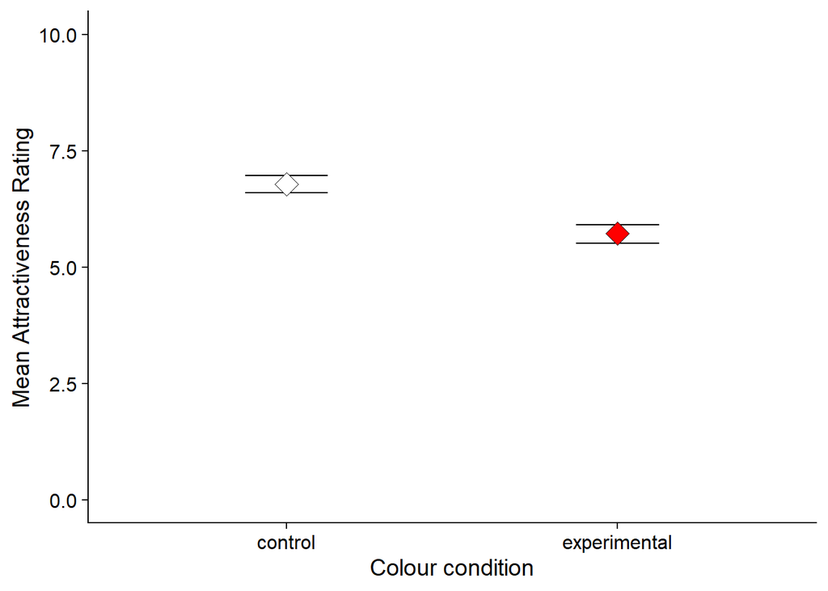

# Discussion

These results contradict the findings from the original study conducted by Elliot et al (2010). They found that colour can influence participants’ ratings of attractiveness without their knowledge. This is because their colour condition had a higher mean rating of attractiveness of 6.79 compared to the control (white) condition that had a mean attractiveness rating of 5.67 (Elliot et al, 2010). Therefore, they accepted their alternative hypothesis. The findings from our study contradict this as the higher mean attractiveness rating was 6.78 in the control condition, compared to 5.72 in the colour condition. This could have been because of the different sample used from the original study and the context in which both studies were conducted. Elliot et al’s study was conducted in 2010, with the position of women in society being a lot different. The decade difference between studies may reflect the changing attitudes of women and the materialism associated with attractiveness. Therefore, it is important to consider how the social context has changed since the original study which questions the ecological and historical validity of the original study.

Further critique to the methodologies comes from the publication bias suggested by Francis (2013). He suggested that some of the findings with null outcomes were not reported or that the reported experiments contaminated the overall conclusions as they were run improperly (Francis, 2013). This increased the likelihood of rejecting the null hypothesis, therefore the alternative hypothesis was accepted. Although Elliot et al’s findings appear to support their hypothesis, they are unreliable due to the possibility of null outcomes deliberately being not included in the report (Francis, 2013). This supports our contradictory findings as they may have also had null outcomes but did not include them due to publication bias. The validity of Elliot et al’s (2010) findings and the application of these is questionable. However, in response to allegations of publication bias, Elliot and Maier (2013) argued that they used their methods as an exploratory test to be used very cautiously (Elliot & Maier, 2013).

Another replication also provides supporting evidence for our findings that contradict Elliot et al (2010). They found that the women wearing the colour red were not viewed as more attractive than the women wearing black or white (Peperkoorn, Roberts, & Pollet, 2016). Theses replication experiments show no supporting evidence of the red effect. This supports that the red effect ideology is outdated and the possibility that the original evidence was subject to publication bias (Francis, 2013).

**Limitations**

The results from our replication study provide a contribution to the research surrounding the red effect, however there are limitations that must be taken into consideration. The data collected for the study was from only female students. This means that the sample population is limited in its diversity and ability to be generalized to the wider population and other cultural contexts. The use of only female participants also makes the findings subject to gender bias, in particular beta bias. A replication could be done with male participants viewing an image of a woman to conclude if there are similar results to female participants.

Moreover, the methodological design of the experiment was limited to the Elliot paradigm. For example, the participants are instructed to look at the photo for only 5 seconds which might not provide enough time for them to really evaluate it (Peperkoorn, Roberts, & Pollet, 2016). Individual differences also need to be considered when reviewing attractiveness because every participant will have different ideas of attractiveness so the subjectivity of this makes the results difficult to validate. A range of diverse looking models in the photos could be used to try and minimise this impact (Young, 2015). Therefore, because the participants only had 5 seconds and only one man, we cannot comment on how the red effect would impact the results if they had longer to view the image and of a diverse range of men. It is also important to consider demand characteristics and impact of social desirability bias due to the use of a self-report measure for the attractiveness ratings.

**Further Research**

The design of the experiment was between-subjects where different participants saw the photo frame in different colours. Each participant being involved in only one condition. Other replications of the red effect experiments have used a within-subjects design where the same participant rates the attractiveness of the man in both colour conditions (Roberts et al, 2010). Future research could try to incorporate both elements of the between-subjects design and the within-subjects design in the same paper and compare the results to see how this impacts perceived attractiveness (Peperkoorn, Roberts, & Pollet, 2016). A longitudinal design may also be valuable as it will show how human mate preferences develop and change over time, taking social contexts into consideration (Peperkoorn, Roberts, & Pollet, 2016).

Furthermore, this study was conducted in a laboratory where participants may have been influenced by demand characteristics due to the unnatural setting (Peperkoorn, Roberts, & Pollet, 2016). Further research could conduct a field experiment replication where attractiveness evaluation is more appropriate. For example, a speed dating scenario where attractiveness rating will be more suited to the situation. In a natural setting, the ratings of attractiveness may be more genuine which would ensure greater validity and reliability.

The findings that apparel style can influence attractiveness could be explored further by using different variables such as clothing style and social status as these factors seem to influence human mate preferences (Hesslinger, Goldbach, & Carbon, 2015). Therefore, instead of investigating the influence of colour, other factors that impact attractiveness could be explored.

# References

Elliot, A. J., Niesta Kayser, D., Greitemeyer, T., Lichtenfeld, S., Gramzow, R. H., Maier, M. A., & Liu, H. (2010). Red, rank, and romance in women viewing men. *Journal of Experimental Psychology: General, 139*(3), 399.

Francis. (2013). Publication bias in “Red, rank, and romance in women viewing men,” by Elliot et al. (2010).

Hesslinger, Goldbach, & Carbon. (2015). Men in red: A reexamination of the red-attractiveness effect. *Psychonomic Bulletin & Review volume.*

Peperkoorn, Roberts, & Pollet. (2016). Revisiting the Red Effect on Attractiveness and Sexual Receptivity: No Effect of the Color Red on Human Mate Preferences.

Roberts et al. (2010). Distinguishing between perceiver and wearer effects in clothing color-associated attributions. *Evolutionary Psychology, 350-364.*

Young. (2015). The effect of red on male perceptions of female attractiveness: Moderation by baseline attractiveness of female faces. *European Journal of Social Psychology, 146-151.*